# R Code Corresponding to the Book *Publication Bias in Meta-Analysis* by Rothstein et al. (2005)

## 7) Failsafe N or File-Drawer Number

```r
# failsafe N for dataset 1

fsn(yi, vi, data=dat1)
```

```
## Fail-safe N Calculation Using the Rosenthal Approach
##
## Observed Significance Level: 0.0072
## Target Significance Level:   0.05
##
## Fail-safe N: 24
```

```r
# failsafe N for dataset 2

fsn(yi, vi, data=dat2)
```

```
## Fail-safe N Calculation Using the Rosenthal Approach
##
## Observed Significance Level: <.0001
## Target Significance Level:   0.05
##
## Fail-safe N: 393
```

```r
# failsafe N for dataset 3

fsn(yi, vi, data=dat3z)
```

```
## Fail-safe N Calculation Using the Rosenthal Approach
##
## Observed Significance Level: <.0001
## Target Significance Level:   0.05
##
## Fail-safe N: 50364
```

Note: The values obtained above differ slightly from those in the book due to two reasons:

1. Some values were rounded intermittently in the book.
2. The `fsn()` function uses (approximate) Wald-type tests for computing the $p$-values which are used as input for Stouffer’s method, while t-tests were conducted for datasets 1 and 3 in the book.

```r
# failsafe N for dataset 1 using Orwin's method

fsn(yi, vi, data=dat1, type="Orwin", target=0.05)
```

```
## Fail-safe N Calculation Using the Orwin Approach
##
## Average Effect Size: 0.0578
## Target Effect Size:  0.0500
##
## Fail-safe N: 3
```

```r
# failsafe N for dataset 2 using Orwin's method

fsn(yi, vi, data=dat2, type="Orwin", target=log(1.05))
```

```
## Fail-safe N Calculation Using the Orwin Approach
##
## Average Effect Size: 0.1858
## Target Effect Size:  0.0488
##
## Fail-safe N: 104
```

```r
# failsafe N for dataset 3 using Orwin's method

fsn(yi, vi, data=dat3r, type="Orwin", target=0.15)
```

```
## Fail-safe N Calculation Using the Orwin Approach
##
## Average Effect Size: 0.4713
## Target Effect Size:  0.1500
##
## Fail-safe N: 343
```

```r
# failsafe N using Orwin's method calculated exactly as described in the book

fsn1 <- fsn(rep(0.06,  nrow(dat1)), type="Orwin", target=0.05)$fsn
fsn2 <- fsn(rep(0.185, nrow(dat2)), type="Orwin", target=0.049)$fsn
fsn3 <- fsn(rep(0.21,  nrow(dat3)), type="Orwin", target=0.15)$fsn
c(fsn1 = fsn1, fsn2 = fsn2, fsn3 = fsn3)
```

```
## fsn1 fsn2 fsn3
##    4  103   64
```

Although the computations underlying Fisher’s method are not difficult, we can make use of the [poolr](https://ozancinar.github.io/poolr/) package to automate things.

```r
# install the 'poolr' package (if it is not already installed) and load it

if (!require(poolr)) {
   install.packages("poolr")
   library(poolr)
}
```

```r
# Fisher's test for dataset 1

pval1 <- c(pnorm(dat1$yi / sqrt(dat1$vi), lower.tail=FALSE))
fisher(pval1)
```

```
## combined p-values with:      Fisher's method
## number of p-values combined: 19
## test statistic:              70.125 ~ chi-square(df = 38)
## adjustment:                  none
## combined p-value:            0.001159823
```

```r
# Fisher's test for dataset 2

pval2 <- c(pnorm(dat2$yi / sqrt(dat2$vi), lower.tail=FALSE))
fisher(pval2)
```

```
## combined p-values with:      Fisher's method
## number of p-values combined: 37
## test statistic:              158.246 ~ chi-square(df = 74)
## adjustment:                  none
## combined p-value:            4.587673e-08
```

```r
# Fisher's test for dataset 3

pval3 <- c(pnorm(dat3z$yi / sqrt(dat3z$vi), lower.tail=FALSE))
fisher(pval3)
```

```
## combined p-values with:      Fisher's method
## number of p-values combined: 160
## test statistic:              2418.5 ~ chi-square(df = 320)
## adjustment:                  none
## combined p-value:            3.477446e-318
```

```r
# Fisher failsafe N for datasets 1

fsn(yi, vi, data=dat1, pool="Fisher")
```

[output not shown]

```r
# Fisher failsafe N for datasets 2

fsn(yi, vi, data=dat2, pool="Fisher")
```

```
## Fail-safe N Calculation Using the Rosenthal Approach
##
## Observed Significance Level: <.0001
## Target Significance Level:   0.05
##
## Fail-safe N: 100
```

```r
# Fisher failsafe N for datasets 3

fsn(yi, vi, data=dat3z, pool="Fisher")
```

```
## Fail-safe N Calculation Using the Rosenthal Approach
##
## Observed Significance Level: <.0001
## Target Significance Level:   0.05
##
## Fail-safe N: 3152
```

The results again differ slightly due to the two reasons outlined earlier.

## 8) The Trim and Fill Method

```r
# log odds ratios and corresponding standard errors as given in Table 8.1

yi  <- c(-0.20, -0.07, 0.04, 0.16, 0.21, 0.27, 0.53, 0.56, 0.80, 1.08, 2.11)
sei <- c( 0.41,  0.18, 0.30, 0.53, 0.51, 0.33, 0.74, 1.08, 0.62, 0.66, 1.55)
```

```r
# random-effects model

res <- rma(yi, sei=sei, method="DL")
res
```

```
## Random-Effects Model (k = 11; tau^2 estimator: DL)
##
## tau^2 (estimated amount of total heterogeneity): 0 (SE = 0.0807)
## tau (square root of estimated tau^2 value):      0
## I^2 (total heterogeneity / total variability):   0.00%
## H^2 (total variability / sampling variability):  1.00
##
## Test for Heterogeneity:
## Q(df = 10) = 7.4675, p-val = 0.6807
##
## Model Results:
##
## estimate      se    zval    pval    ci.lb   ci.ub
##   0.1081  0.1174  0.9204  0.3574  -0.1221  0.3383
##
## ---
## Signif. codes:  0 '***' 0.001 '**' 0.01 '*' 0.05 '.' 0.1 ' ' 1
```

```r
# estimated odds ratio (and 95% CI)

predict(res, transf=exp, digits=2)
```

```
##  pred ci.lb ci.ub pi.lb pi.ub
##  1.11  0.89  1.40  0.89  1.40
```

```r
# trim and fill analysis

taf <- trimfill(res)
taf
```

```
## Estimated number of missing studies on the left side: 5 (SE = 2.0410)
##
## Random-Effects Model (k = 16; tau^2 estimator: DL)
##
## tau^2 (estimated amount of total heterogeneity): 0 (SE = 0.0844)
## tau (square root of estimated tau^2 value):      0
## I^2 (total heterogeneity / total variability):   0.00%
## H^2 (total variability / sampling variability):  1.00
##
## Test for Heterogeneity:
## Q(df = 15) = 14.8758, p-val = 0.4604
##
## Model Results:
##
## estimate      se    zval    pval    ci.lb   ci.ub
##   0.0147  0.1115  0.1322  0.8948  -0.2037  0.2332
##
## ---
## Signif. codes:  0 '***' 0.001 '**' 0.01 '*' 0.05 '.' 0.1 ' ' 1
```

```r
# estimated odds ratio (and 95% CI)

predict(taf, transf=exp, digits=2)
```

```
##  pred ci.lb ci.ub pi.lb pi.ub
##  1.01  0.82  1.26  0.82  1.26
```

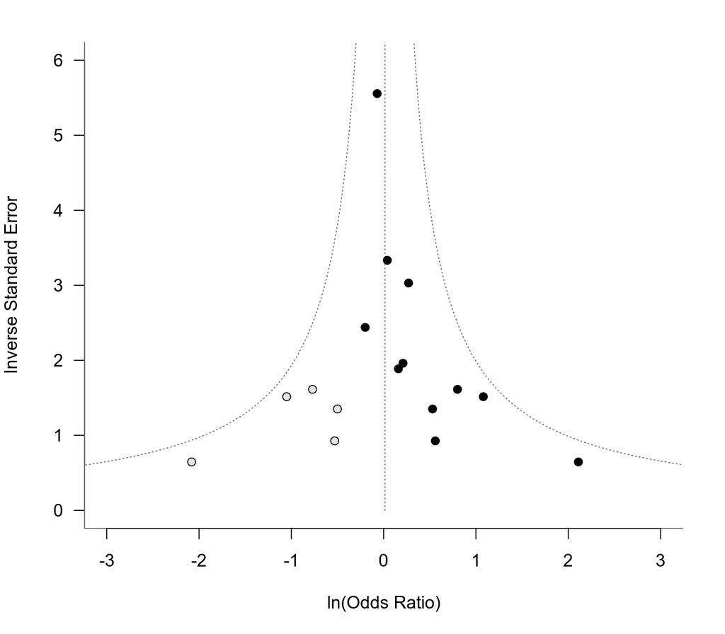

```r
# Figure 8.2

par(mar=c(5,4,2,2))

funnel(taf, yaxis="seinv", xlab="ln(Odds Ratio)", back=NA, las=1,
       xlim=c(-3,3), ylim=c(1e-6,6), steps=7)
```

```r
# trim and fill analysis for dataset 2

res <- rma(yi, vi=vi, data=dat2, method="DL")
taf <- trimfill(res)
pred.res <- predict(res, transf=exp)
pred.taf <- predict(taf, transf=exp)

tab <- data.frame(
   k     = c(res$k, taf$k),
   k0    = c(0, taf$k0),
   theta = c(pred.res$pred, pred.taf$pred),
   ci.lb = c(pred.res$ci.lb, pred.taf$ci.lb),
   ci.ub = c(pred.res$ci.ub, pred.taf$ci.ub))
rownames(tab) <- c("Observed", "Filled")
dfround(tab, c(0,0,2,2,2))
```

```
##           k k0 theta ci.lb ci.ub
## Observed 37  0  1.24  1.13  1.36
## Filled   44  7  1.19  1.08  1.31
```

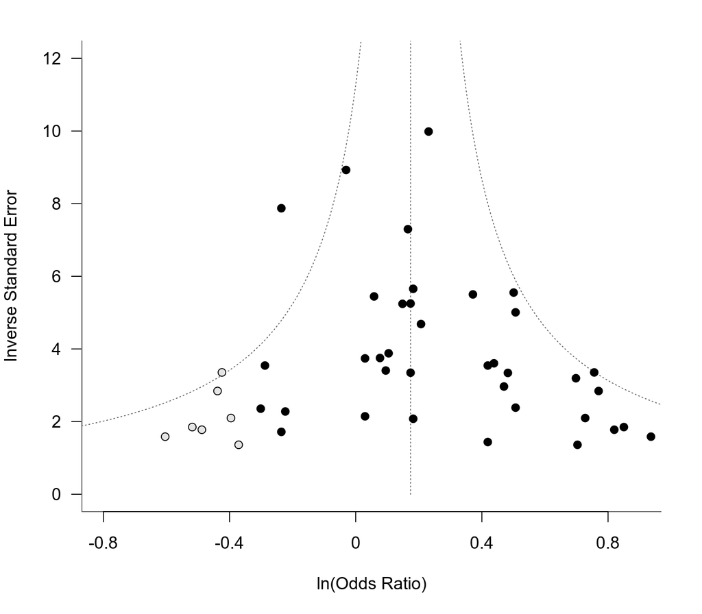

```r
# Figure 8.3

par(mar=c(5,4,2,2))

funnel(taf, yaxis="seinv", xlab="ln(Odds Ratio)", back=NA, las=1,
       xlim=c(-0.8,0.9), at=c(-0.8, -0.4, 0, 0.4, 0.8), ylim=c(1e-6,12), steps=7)
```

```r
# trim and fill analysis for dataset 3 - structured interviews

res <- rma(yi, vi=vi, data=subset(dat3z, struct=="s"), method="DL")
taf <- trimfill(res)
taf
```

```
## Estimated number of missing studies on the left side: 19 (SE = 6.7575)
##
## Random-Effects Model (k = 125; tau^2 estimator: DL)
##
## tau^2 (estimated amount of total heterogeneity): 0.0637 (SE = 0.0162)
## tau (square root of estimated tau^2 value):      0.2523
## I^2 (total heterogeneity / total variability):   87.13%
## H^2 (total variability / sampling variability):  7.77
##
## Test for Heterogeneity:
## Q(df = 124) = 963.6530, p-val < .0001
##
## Model Results:
##
## estimate      se    zval    pval   ci.lb   ci.ub
##   0.2053  0.0263  7.7997  <.0001  0.1537  0.2569  ***
##
## ---
## Signif. codes:  0 '***' 0.001 '**' 0.01 '*' 0.05 '.' 0.1 ' ' 1
```

```r
pred.res <- predict(res, transf=transf.ztor)
pred.taf <- predict(taf, transf=transf.ztor)

tab <- data.frame(
   k     = c(res$k, taf$k),
   k0    = c(0, taf$k0),
   theta = c(pred.res$pred, pred.taf$pred),
   ci.lb = c(pred.res$ci.lb, pred.taf$ci.lb),
   ci.ub = c(pred.res$ci.ub, pred.taf$ci.ub))
rownames(tab) <- c("Observed", "Filled")
dfround(tab, c(0,0,3,3,3))
```

```
##            k k0 theta ci.lb ci.ub
## Observed 106  0 0.266 0.223 0.308
## Filled   125 19 0.202 0.153 0.251
```

```r
# trim and fill analysis for dataset 3 - unstructured interviews

res <- rma(yi, vi=vi, data=subset(dat3z, struct=="u"), method="DL")
taf <- trimfill(res)
taf
```

```
## Estimated number of missing studies on the left side: 0 (SE = 3.3481)
##
## Random-Effects Model (k = 39; tau^2 estimator: DL)
##
## tau^2 (estimated amount of total heterogeneity): 0.0123 (SE = 0.0078)
## tau (square root of estimated tau^2 value):      0.1107
## I^2 (total heterogeneity / total variability):   69.35%
## H^2 (total variability / sampling variability):  3.26
##
## Test for Heterogeneity:
## Q(df = 38) = 123.9901, p-val < .0001
##
## Model Results:
##
## estimate      se    zval    pval   ci.lb   ci.ub
##   0.1891  0.0257  7.3546  <.0001  0.1387  0.2395  ***
##
## ---
## Signif. codes:  0 '***' 0.001 '**' 0.01 '*' 0.05 '.' 0.1 ' ' 1
```

```r
pred.res <- predict(res, transf=transf.ztor)
pred.taf <- predict(taf, transf=transf.ztor)

tab <- data.frame(
   k     = c(res$k, taf$k),
   k0    = c(0, taf$k0),
   theta = c(pred.res$pred, pred.taf$pred),
   ci.lb = c(pred.res$ci.lb, pred.taf$ci.lb),
   ci.ub = c(pred.res$ci.ub, pred.taf$ci.ub))
rownames(tab) <- c("Observed", "Filled")
dfround(tab, c(0,0,3,3,3))
```

```
##           k k0 theta ci.lb ci.ub
## Observed 39  0 0.187 0.138 0.235
## Filled   39  0 0.187 0.138 0.235
```

Note: One could continue to do the same with other subgroups, as illustrated in Table 8.3.

```r
# trim and fill analysis for dataset 1

res <- rma(yi, vi=vi, data=dat1, method="DL")
taf <- trimfill(res)
taf
```

```
## Estimated number of missing studies on the left side: 3 (SE = 2.9465)
##
## Random-Effects Model (k = 22; tau^2 estimator: DL)
##
## tau^2 (estimated amount of total heterogeneity): 0.0474 (SE = 0.0266)
## tau (square root of estimated tau^2 value):      0.2176
## I^2 (total heterogeneity / total variability):   61.80%
## H^2 (total variability / sampling variability):  2.62
##
## Test for Heterogeneity:
## Q(df = 21) = 54.9740, p-val < .0001
##
## Model Results:
##
## estimate      se    zval    pval    ci.lb   ci.ub
##   0.0273  0.0636  0.4282  0.6685  -0.0975  0.1520
##
## ---
## Signif. codes:  0 '***' 0.001 '**' 0.01 '*' 0.05 '.' 0.1 ' ' 1
```

```r
tab <- data.frame(
   k     = c(res$k, taf$k),
   k0    = c(0, taf$k0),
   theta = c(coef(res), coef(taf)),
   ci.lb = c(res$ci.lb, taf$ci.lb),
   ci.ub = c(res$ci.ub, taf$ci.ub))
rownames(tab) <- c("Observed", "Filled")
dfround(tab, c(0,0,3,3,3))
```

```
##           k k0 theta  ci.lb ci.ub
## Observed 19  0 0.084 -0.023 0.191
## Filled   22  3 0.027 -0.097 0.152
```

Note: One could do the same within the low- and high-contact subgroups, as illustrated in Table 8.4.

## 9) Selection Method Approaches

```r
# random-effects model for dataset 2 (unadjusted estimates)

res.un <- rma(yi, vi, data=dat2, method="ML")
res.un
```

```
## Random-Effects Model (k = 37; tau^2 estimator: ML)
##
## tau^2 (estimated amount of total heterogeneity): 0.0204 (SE = 0.0165)
## tau (square root of estimated tau^2 value):      0.1427
## I^2 (total heterogeneity / total variability):   27.62%
## H^2 (total variability / sampling variability):  1.38
##
## Test for Heterogeneity:
## Q(df = 36) = 47.4979, p-val = 0.0952
##
## Model Results:
##
## estimate      se    zval    pval   ci.lb   ci.ub
##   0.2171  0.0486  4.4712  <.0001  0.1219  0.3123  ***
##
## ---
## Signif. codes:  0 '***' 0.001 '**' 0.01 '*' 0.05 '.' 0.1 ' ' 1
```

```r
# Vevea and Hedges (1995) model (weight function estimated)

sel <- selmodel(res.un, type="stepfun", steps=c(0.05, 0.10, 0.50, 1.00))
sel
```

```
## Random-Effects Model (k = 37; tau^2 estimator: ML)
##
## tau^2 (estimated amount of total heterogeneity): 0.0307 (SE = 0.0271)
## tau (square root of estimated tau^2 value):      0.1753
##
## Test for Heterogeneity:
## LRT(df = 1) = 3.9537, p-val = 0.0468
##
## Model Results:
##
## estimate      se    zval    pval    ci.lb   ci.ub
##   0.1217  0.1299  0.9373  0.3486  -0.1328  0.3763
##
## Test for Selection Model Parameters:
## LRT(df = 3) = 7.0661, p-val = 0.0698
##
## Selection Model Results:
##
##                    k  estimate      se     zval    pval   ci.lb   ci.ub
## 0    < p <= 0.05   7    1.0000     ---      ---     ---     ---     ---
## 0.05 < p <= 0.1    8    2.4221  1.6609   0.8562  0.3919  0.0000  5.6773
## 0.1  < p <= 0.5   16    0.9775  0.8204  -0.0274  0.9782  0.0000  2.5855
## 0.5  < p <= 1      6    0.3967  0.4692  -1.2857  0.1986  0.0000  1.3164
##
## ---
## Signif. codes:  0 '***' 0.001 '**' 0.01 '*' 0.05 '.' 0.1 ' ' 1
```

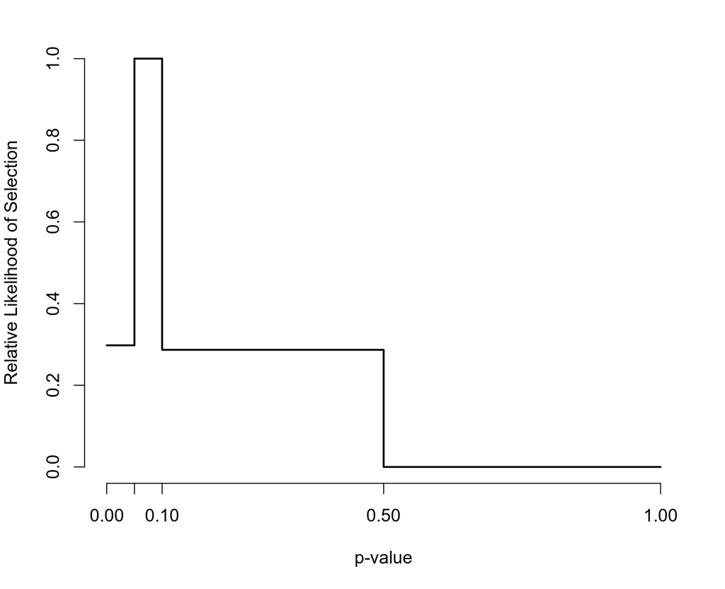

```r
# Figure 9.1

par(mar=c(5,4,2,2))
plot(sel, scale=TRUE, rug=FALSE, bty="n", xaxt="n")
axis(side=1, at=c(0,sel$steps))
```

```r
# Table 9.3: Specification of weights for a priori weight functions

ssp <- data.frame(
 steps = c(0.005, 0.01, 0.05, 0.10, 0.25, 0.35, 0.50, 0.65, 0.75, 0.90, 0.95, 0.99, 0.995, 1),
 weak.1 = c(1, 0.99, 0.95, 0.90, 0.80, 0.75, 0.65, 0.60, 0.55, 0.50, 0.50, 0.50, 0.50, 0.50),
 stro.1 = c(1, 0.99, 0.90, 0.75, 0.60, 0.55, 0.50, 0.45, 0.40, 0.35, 0.30, 0.25, 0.20, 0.10),
 weak.2 = c(1, 0.99, 0.95, 0.90, 0.80, 0.75, 0.60, 0.60, 0.75, 0.80, 0.90, 0.95, 0.99, 1.00),
 stro.2 = c(1, 0.99, 0.90, 0.75, 0.60, 0.50, 0.25, 0.25, 0.50, 0.60, 0.75, 0.90, 0.99, 1.00))
ssp
```

```
##    steps weak.1 stro.1 weak.2 stro.2
## 1  0.005   1.00   1.00   1.00   1.00
## 2  0.010   0.99   0.99   0.99   0.99
## 3  0.050   0.95   0.90   0.95   0.90
## 4  0.100   0.90   0.75   0.90   0.75
## 5  0.250   0.80   0.60   0.80   0.60
## 6  0.350   0.75   0.55   0.75   0.50
## 7  0.500   0.65   0.50   0.60   0.25
## 8  0.650   0.60   0.45   0.60   0.25
## 9  0.750   0.55   0.40   0.75   0.50
## 10 0.900   0.50   0.35   0.80   0.60
## 11 0.950   0.50   0.30   0.90   0.75
## 12 0.990   0.50   0.25   0.95   0.90
## 13 0.995   0.50   0.20   0.99   0.99
## 14 1.000   0.50   0.10   1.00   1.00
```

```r
# apply a priori weight functions

res.weak.1 <- selmodel(res.un, type="stepfun", steps=ssp$steps, delta=ssp$weak.1)
res.stro.1 <- selmodel(res.un, type="stepfun", steps=ssp$steps, delta=ssp$stro.1)
res.weak.2 <- selmodel(res.un, type="stepfun", steps=ssp$steps, delta=ssp$weak.2)
res.stro.2 <- selmodel(res.un, type="stepfun", steps=ssp$steps, delta=ssp$stro.2)

# Table 9.4 (but transposed)

tab <- data.frame(logOR = c(coef(res.un), coef(res.weak.1)$beta, coef(res.stro.1)$beta,
                                          coef(res.weak.2)$beta, coef(res.stro.2)$beta),
                  varcomp = c(res.un$tau2, res.weak.1$tau2, res.stro.1$tau2,
                                           res.weak.2$tau2, res.stro.2$tau2))
rownames(tab) <- c("unadjusted", "weak one-tailed selection", "strong one-tailed selection",
                                 "weak two-tailed selection", "strong two-tailed selection")
dfround(tab, c(2,3))
```

```
##                             logOR varcomp
## unadjusted                   0.22   0.020
## weak one-tailed selection    0.16   0.019
## strong one-tailed selection  0.13   0.018
## weak two-tailed selection    0.19   0.015
## strong two-tailed selection  0.15   0.009
```

```r
# install the 'metasens' package (if it is not already installed) and load it

if (!require(metasens)) {
   install.packages("metasens")
   library(metasens)
}
```

```r
# Copas and Shi (2001) model (selection depending on both T and sigma)

res <- metagen(yi, sqrt(vi), method.tau="ML", data=dat2)
sav <- copas(res)
#plot(sav)
summary(sav)
```

```
## Copas selection model analysis
##
##               p.publ                   95%-CI  tau^2    tau    p.trt  p.rsb  N
##               1.0000 0.2171 [ 0.1182; 0.3160] 0.0204 0.1427 < 0.0001 0.0371  0
##               0.9296 0.2003 [ 0.1010; 0.2996] 0.0189 0.1374 < 0.0001 0.0641  2
##               0.8612 0.1801 [ 0.0820; 0.2782] 0.0184 0.1358   0.0003 0.1142  4
##               0.8068 0.1602 [ 0.0648; 0.2556] 0.0182 0.1349   0.0010 0.1657  5
##               0.6867 0.1394 [ 0.0226; 0.2562] 0.0163 0.1276   0.0193 0.2431 11
##               0.5989 0.1197 [-0.0036; 0.2429] 0.0153 0.1236   0.0571 0.3482 16
##               0.4901 0.0991 [-0.0356; 0.2337] 0.0142 0.1192   0.1494 0.4843 26
##
##    Adjusted estimate 0.1801 [ 0.0820; 0.2782] 0.0184 0.1358   0.0003 0.1142  4
##  Unadjusted estimate 0.2171 [ 0.1219; 0.3123] 0.0204 0.1427 < 0.0001
##
## Significance level for test of residual selection bias: 0.1
##
##                        min    max
##  range of gamma0:  -0.4535 2.0000
##  range of gamma1:   0.0000 0.1496
##
## Largest standard error (SE): 0.735
##
## Range of probability publishing trial with largest SE:
##     min    max
##  0.3251 0.9862
##
## Calculation of orthogonal line:
##
##  level nobs adj.r.square      slope   se.slope
##   0.04    6    0.9916557 -1.1278233 0.04622816
##   0.06   13    0.9868226 -1.6880865 0.05628042
##   0.08   19    0.9873009 -2.1817836 0.05830170
##   0.10   27    0.9900491 -2.6612960 0.05231498
##   0.12   26    0.9975215 -3.3608319 0.03350338
##   0.14   26    0.9542003 -3.4079163 0.14918114
##   0.14    5   -0.2955325  0.1343782 0.45419392
##   0.16   25    0.9855488 -4.7644080 0.11772888
##   0.18   23    0.9927567 -4.6554077 0.08476573
##   0.20   23    0.9921361 -5.1308523 0.09737182
##
##  Legend:
##  p.publ - Probability of publishing study with largest SE
##  p.trt  - P-value for test of overall treatment effect
##  p.rsb  - P-value for test of residual selection bias
##  N      - Estimated number of unpublished studies
```

Note that this analysis is a bit different than the one presented in the book (where parameters $a$ and $b$ are fixed to specific values).

The analyses of dataset 3 (on the validity of the employment interview) presented in this chapter cannot be replicated because the meta-regression model considered here includes a moderator that is not actually part of the dataset provided in Appendix A (whether the interview was conducted for research or for administrative reasons). Hence, we will move on to the analysis of dataset 1.

```r
# meta-regression model for dataset 1 (unadjusted estimates)

res.un <- rma(yi, vi, mods = ~ weeks, data=dat1, method="FE")
res.un
```

```
## Fixed-Effects with Moderators Model (k = 19)
##
## I^2 (residual heterogeneity / unaccounted variability): 0.00%
## H^2 (unaccounted variability / sampling variability):   0.99
## R^2 (amount of heterogeneity accounted for):            47.82%
##
## Test for Residual Heterogeneity:
## QE(df = 17) = 16.7735, p-val = 0.4698
##
## Test of Moderators (coefficient 2):
## QM(df = 1) = 17.2649, p-val < .0001
##
## Model Results:
##
##          estimate      se     zval    pval    ci.lb    ci.ub
## intrcpt    0.3494  0.0792   4.4143  <.0001   0.1943   0.5046  ***
## weeks     -0.3709  0.0893  -4.1551  <.0001  -0.5459  -0.1960  ***
##
## ---
## Signif. codes:  0 '***' 0.001 '**' 0.01 '*' 0.05 '.' 0.1 ' ' 1
```

```r
# Vevea and Hedges (1995) model (weight function estimated)

sel <- selmodel(res.un, type="stepfun", steps=c(0.05, 0.30, 1.00))
sel
```

```
## Fixed-Effects with Moderators Model (k = 19)
##
## Test of Moderators (coefficient 2):
## QM(df = 1) = 11.0191, p-val = 0.0009
##
## Model Results:
##
##          estimate      se     zval    pval    ci.lb    ci.ub
## intrcpt    0.3206  0.1115   2.8745  0.0040   0.1020   0.5391   **
## weeks     -0.3625  0.1092  -3.3195  0.0009  -0.5766  -0.1485  ***
##
## Test for Selection Model Parameters:
## LRT(df = 2) = 0.4323, p-val = 0.8056
##
## Selection Model Results:
##
##                   k  estimate      se     zval    pval   ci.lb   ci.ub
## 0    < p <= 0.05  4    1.0000     ---      ---     ---     ---     ---
## 0.05 < p <= 0.3   6    0.8924  0.7987  -0.1347  0.8928  0.0000  2.4578
## 0.3  < p <= 1     9    0.5603  0.6422  -0.6846  0.4936  0.0000  1.8191
##
## ---
## Signif. codes:  0 '***' 0.001 '**' 0.01 '*' 0.05 '.' 0.1 ' ' 1
```

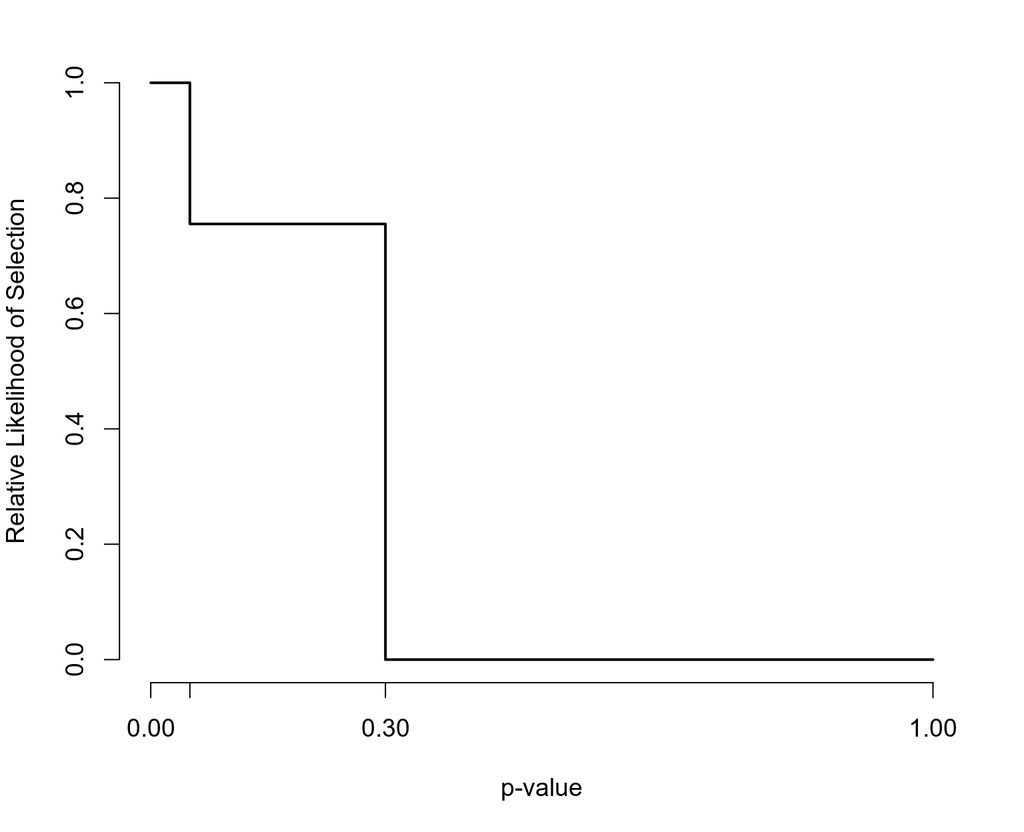

```r
# Figure 9.3

par(mar=c(5,4,2,2))
plot(sel, scale=TRUE, rug=FALSE, bty="n", xaxt="n")
axis(side=1, at=c(0,sel$steps))
```

```r
# apply a priori weight functions

res.weak.1 <- selmodel(res.un, type="stepfun", steps=ssp$steps, delta=ssp$weak.1)
res.stro.1 <- selmodel(res.un, type="stepfun", steps=ssp$steps, delta=ssp$stro.1)
res.weak.2 <- selmodel(res.un, type="stepfun", steps=ssp$steps, delta=ssp$weak.2)
res.stro.2 <- selmodel(res.un, type="stepfun", steps=ssp$steps, delta=ssp$stro.2)

# Table 9.10 (but transposed)

tab <- data.frame(logOR = rbind(coef(res.un), coef(res.weak.1)$beta, coef(res.stro.1)$beta,
                                          coef(res.weak.2)$beta, coef(res.stro.2)$beta))
colnames(tab) <- names(coef(res.un))
rownames(tab) <- c("unadjusted", "weak one-tailed selection", "strong one-tailed selection",
                                 "weak two-tailed selection", "strong two-tailed selection")
dfround(tab, 2)
```

```
##                             intrcpt weeks
## unadjusted                     0.35 -0.37
## weak one-tailed selection      0.32 -0.37
## strong one-tailed selection    0.30 -0.36
## weak two-tailed selection      0.33 -0.35
## strong two-tailed selection    0.29 -0.31
```

As far as I can tell, the `copas()` function from the metasens package cannot handle meta-regression models. Hence, this part cannot be reproduced (without implementing the methods described on pages 157-158).

## 11) Software for Publication Bias

```r
# fit an equal-effects model to dataset 2 and obtain the estimated odds ratio (with 95% CI)

res <- rma(yi, vi, data=dat2, method="EE", slab=paste0(author, ", ", year))
predict(res, transf=exp, digits=3)
```

```
##   pred ci.lb ci.ub
##  1.204 1.119 1.295
```

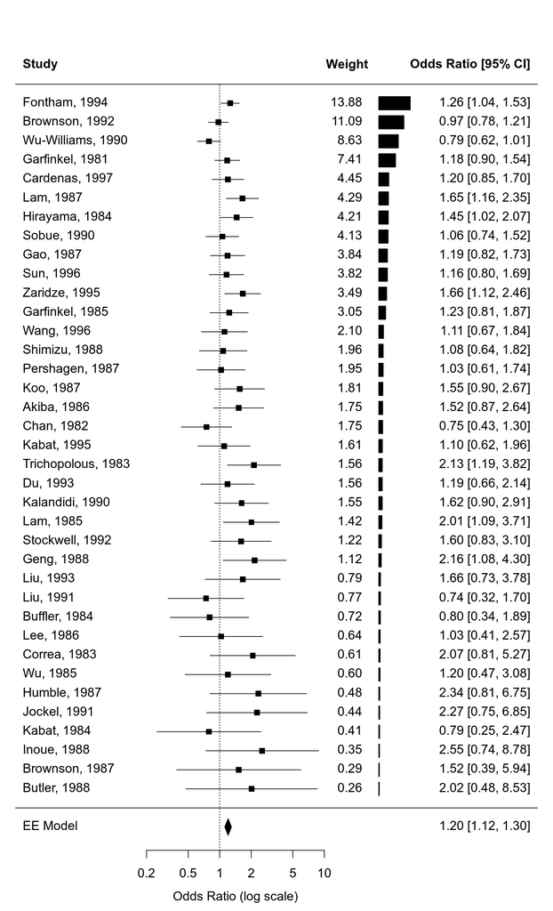

```r
# Figure 11.1

par(mar=c(4,4,2,2))

wi <- fmtx(weights(res), digits=2)

forest(res, atransf=exp, psize=1, header=TRUE, xlim=c(-4.5,7), ylim=c(-0.6,40),
       at=log(c(0.2, 0.5, 1, 2, 5, 10)), efac=c(0,1),
       ilab=wi, ilab.xpos=3.3, ilab.pos=2, order="prec")
text(2.8, 39, "Weight", font=2)

wi <- rev(weights(res)[order(dat2$vi)])
invisible(sapply(seq_along(wi), function(i) rect(3.5, i-0.35, 3.5+wi[i]/20, i+0.35, col="black")))
```

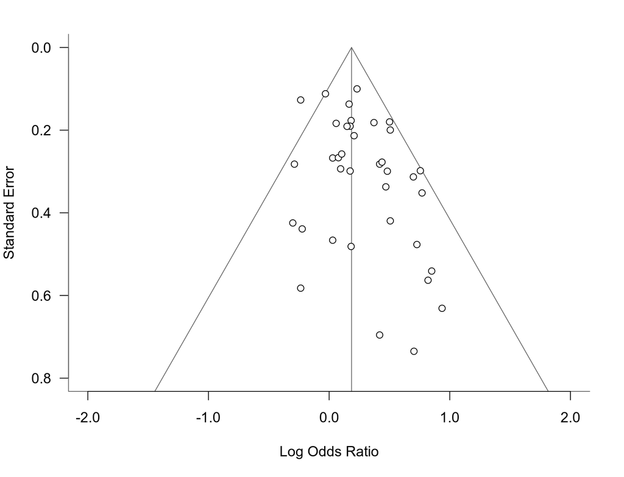

```r
# Figure 11.2

par(mar=c(5,4,2,2))

funnel(res, xlim=c(-2,2), ylim=c(0,0.8), las=1, digits=1,
       back=NA, shade=NA, hlines=NA, lty=1, pch=21, bg="white")
```

```r
# rank correlation test (note: a one-sided p-value is given in the book)

ranktest(res, digits=3)
```

```
## Rank Correlation Test for Funnel Plot Asymmetry
##
## Kendall's tau = 0.144, p = 0.216
```

```r
# Egger's test

regtest(res, model="lm", digits=3)
```

```
## Regression Test for Funnel Plot Asymmetry
##
## Model:     weighted regression with multiplicative dispersion
## Predictor: standard error
##
## Test for Funnel Plot Asymmetry: t = 2.382, df = 35, p = 0.023
## Limit Estimate (as sei -> 0):   b = 0.005 (CI: -0.169, 0.179)
```

```r
# failsafe N

fsn(yi, vi, data=dat2)
```

```
## Fail-safe N Calculation Using the Rosenthal Approach
##
## Observed Significance Level: <.0001
## Target Significance Level:   0.05
##
## Fail-safe N: 393
```

```r
# failsafe N (Orwin's method)

fsn(yi, vi, data=dat2, type="Orwin", target=log(1.05))
```

```
## Fail-safe N Calculation Using the Orwin Approach
##
## Average Effect Size: 0.1858
## Target Effect Size:  0.0488
##
## Fail-safe N: 104
```

```r
# trim and fill analysis

taf <- trimfill(res)
predict(taf, transf=exp, digits=3)
```

```
##   pred ci.lb ci.ub
##  1.168 1.088 1.255
```

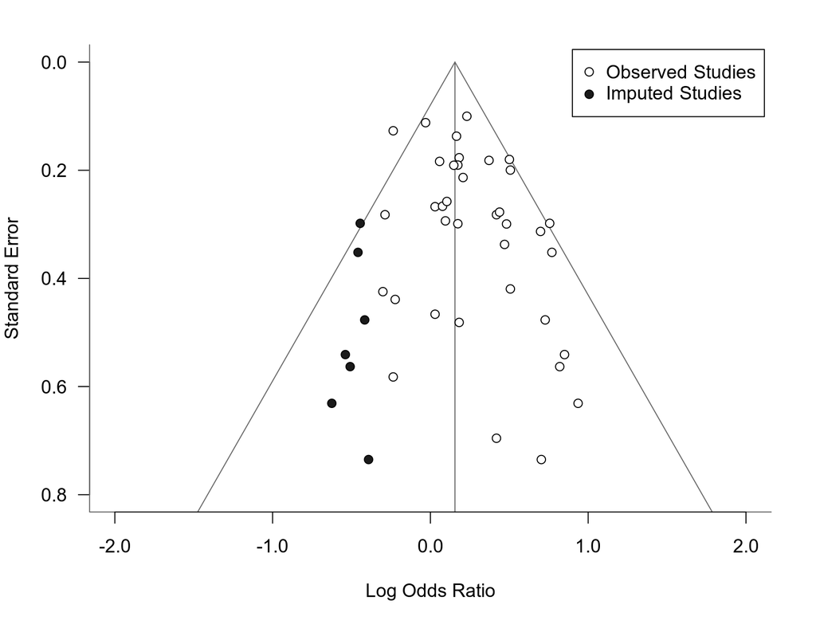

```r
# Figure 11.4

par(mar=c(5,4,2,2))

funnel(taf, xlim=c(-2,2), ylim=c(0,0.8), las=1, digits=1,
       back=NA, shade=NA, hlines=NA, lty=1,
       pch=21, bg=c("white", "gray10"), legend=list(show=NA))
```

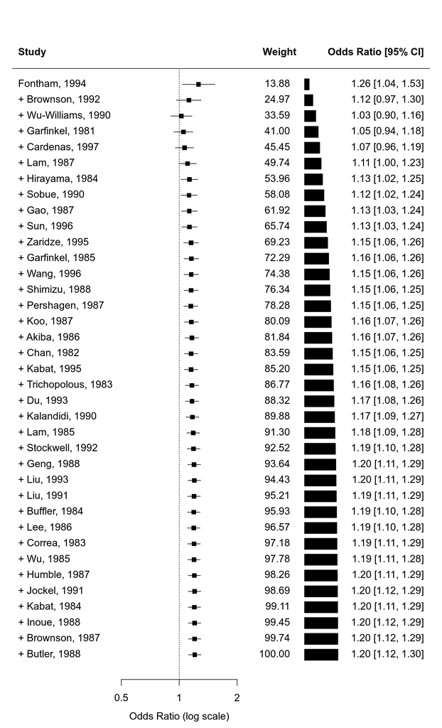

```r
# Figure 11.5: Cumulative forest plot

sav <- cumul(res, order=vi)

wi <- cumsum(weights(res)[order(dat2$vi)])
wi <- fmtx(wi, digits=2)

par(mar=c(4,4,2,2))

forest(sav, atransf=exp, psize=1, header=TRUE, xlim=c(-2,3), ylim=c(1,40),
       at=log(c(0.5, 1, 2)), efac=c(0,1), ilab=wi, ilab.xpos=1.4, ilab.pos=2)
text(1.2, 39, "Weight", font=2)

wi <- rev(cumsum(weights(res)[order(dat2$vi)]))
invisible(sapply(seq_along(wi), function(i) rect(1.5, i-0.35, 1.5+wi[i]/250, i+0.35, col="black")))
```

## License

This documented is licensed under the following license: [CC Attribution-Noncommercial-Share Alike 4.0 International](http://creativecommons.org/licenses/by-nc-sa/4.0/).